# Peer-graded Assignment: Practical Machine Learning

Steven Michiels

4/22/2020

# Executive summary

# Data cleaning and exploration

We load the training and testing data from the provided URL’s. The training data consists of 19622 observations of 159 predictors and a 5-level factor outcome (A, B, C, D or E). A hold-out test set is already provided, consisting of 20 observations. Using the is.na command on all the columns, we see that many predictors barely contain any observation. We verify that these columns do not contain any useful information using the near-zero variance function and **filter out** these columns. We manually observe that the first seven columns neither contain any useful information, so we filter these out as well. This leaves us with **52 predictors**.

To get a feeling of the variance in the predictors, we perform a **principal component analysis**. The cumulative variance proportion is not dominated by few predictors, as instead many predictors make smaller contributions. Therefore, instead of explicit feature selection, we will make use of the **inherent feature importance selection** of the **random forest algorithm** during model building.

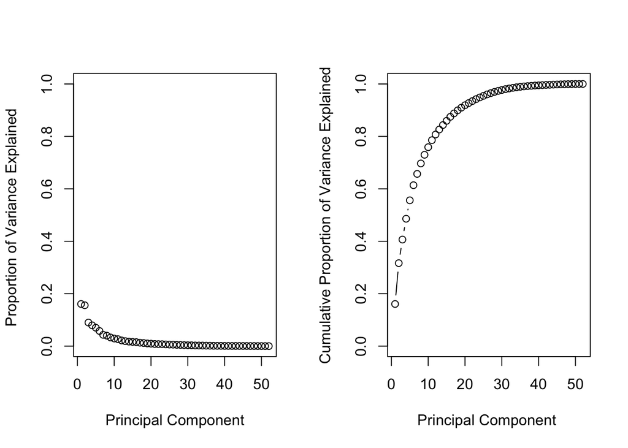

# Model building and evaluation

We create a random forest model using 5-fold cross validation, which will allow us to estimate the out-of-sample error. The training takes around 40 minutes on a MacBook Pro 2016 with CPU.

The random forest algorithm by default tries three different numbers of variables randomly sampled at each split, the mtry. We use the CARET trainControl function with option savePredictions to ‘final’. As such, the predicted outcomes are saved for the cross-validation results of the model for the finally selected value for mtry, in this case 27. This allows us to create a **confusionMatrix** for the **cross-validated results**.

```
##           Reference
## Prediction    A    B    C    D    E
##          A 5574   23    0    0    0
##          B    3 3767   12    0    1
##          C    1    7 3400   34    3
##          D    0    0   10 3180   10
##          E    2    0    0    2 3593
```

```
##       Accuracy          Kappa  AccuracyLower  AccuracyUpper   AccuracyNull
##      0.9944960      0.9930376      0.9933586      0.9954828      0.2843747
## AccuracyPValue  McnemarPValue
##      0.0000000            NaN
```

We obtain an **accuracy within the 95% CI [99.3%,99.5%]**. We can **plot** the **most important predictors per class** and the **overall predictor importance**.

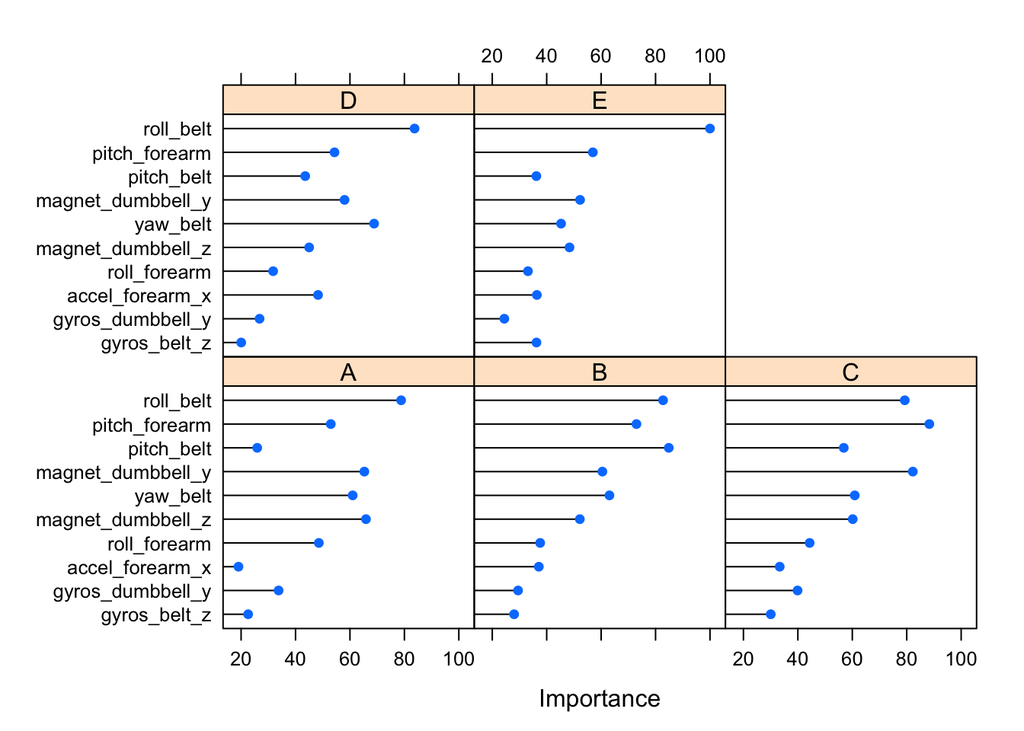

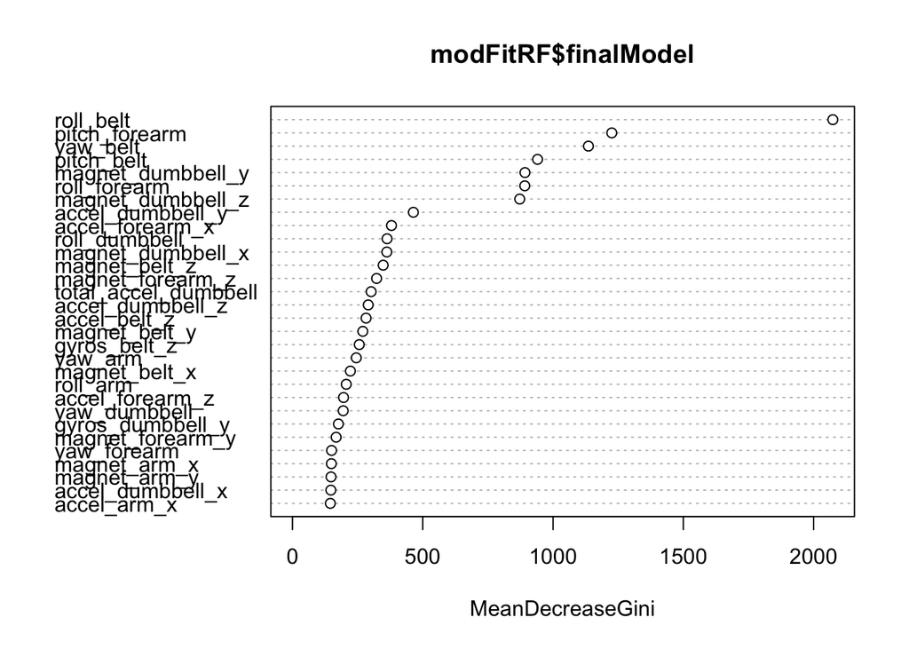

As we’ve obtained an **excellent cross-validated accuracy**, this model will be **used** for the **prediction of the test cases**.

It should be noted that strictly speaken the 5-fold cross-validation was not necessary to obtain an estimate for the out-of-sample error, since the default method of random forest uses bootstrapping. As such, only 63% of the observations are effectively used for the model training. The remaining out-of-bag (oob) observation can be used as well to estimate the out-of-sample error. A random forest without cross-validation was built as well and the estimated oob-error was .42%, which is in line with the cross-validated out-of-sample error.

The **final predictions** using the **random forest built using 5-fold cross-validation** are:

```r
test_predictions = predict(modFitRF, newdata=testing)
test_predictions
```

```
##  [1] B A B A A E D B A A B C B A E E A B B B
## Levels: A B C D E
```